# Win‐wins for biodiversity and ecosystem service conservation depend on the trophic levels of the species providing services - Xiao - 2018 - Journal of Applied Ecology - Wiley Online Library

[Journal of Applied Ecology](https://besjournals.onlinelibrary.wiley.com/journal/13652664)

[Volume 55, Issue 5](https://besjournals.onlinelibrary.wiley.com/toc/13652664/2018/55/5) p. 2160-2170

[figure not shown]

RESEARCH ARTICLE

Free Access

# Win‐wins for biodiversity and ecosystem service conservation depend on the trophic levels of the species providing services

[Hui Xiao](https://besjournals.onlinelibrary.wiley.com/action/doSearch?ContribAuthorStored=Xiao%2C+Hui)

[Laura E. Dee](https://besjournals.onlinelibrary.wiley.com/action/doSearch?ContribAuthorStored=Dee%2C+Laura+E)

[Iadine Chadès](https://besjournals.onlinelibrary.wiley.com/action/doSearch?ContribAuthorStored=Chad%C3%A8s%2C+Iadine)

[Nathalie Peyrard](https://besjournals.onlinelibrary.wiley.com/action/doSearch?ContribAuthorStored=Peyrard%2C+Nathalie)

[Régis Sabbadin](https://besjournals.onlinelibrary.wiley.com/action/doSearch?ContribAuthorStored=Sabbadin%2C+R%C3%A9gis)

[Martin Stringer](https://besjournals.onlinelibrary.wiley.com/action/doSearch?ContribAuthorStored=Stringer%2C+Martin)

[Eve McDonald‐Madden](https://besjournals.onlinelibrary.wiley.com/action/doSearch?ContribAuthorStored=McDonald-Madden%2C+Eve)

First published: 09 June 2018

https://doi.org/10.1111/1365-2664.13192

Citations: 9

## 1 INTRODUCTION

Human activities have severely degraded ecosystems, including species extinctions and loss of ecosystem services (ES) considered essential for human wellbeing (Assessment, 2005). As a result, how to best conserve both species and services has attracted significant attention in scientific and management fields (Daily et al., 2009; Dee, De Lara, Costello, & Gaines, 2017; Isbell, Tilman, Polasky, & Loreau, 2015; Isbell et al., 2017; Mace, 2014). Historically, the protection of species has been the primary goal of conservation (Soule & Wilcox, 1980). However, in recent years, conservation has shifted focus towards species that provide specific services to humans (Mace, 2014; Martin, Ballance, & Groves, 2016). This shift has generated substantial debate (Kareiva, 2014; Kareiva & Marvier, 2012; Soulé, 2014a, 2014b), with some arguing that protecting species for their services ignores their intrinsic value, potentially driving further biodiversity declines (Miller, Soulé, & Terborgh, 2014). Others, however, suggest that simultaneously achieving both biodiversity and ES outcomes is possible (Balvanera et al., 2014; Dee et al., 2017; Mace, Norris, & Fitter, 2012; Polasky et al., 2012). For example, diverse carbon policy mechanisms have been evaluated to achieve carbon and biodiversity co‐benefits (Bryan et al., 2016). Equally, studies focused on particular places or services suggest win‐win outcomes are rare and trade‐offs are more common (Chan, Shaw, Cameron, Underwood, & Daily, 2006; Howe, Suich, Vira, & Mace, 2014; Nelson et al., 2009). For instance, when ecosystem services are provided by a small number of species with a low risk of loss, a strategy aimed at conserving threatened biodiversity may not necessarily enhance service provision (Kleijn et al., 2015). A broader assessment of conditions that will lead to these trade‐offs is still needed to inform the protection of both biodiversity and ecosystem services. To understand trade‐offs and their implications, it is imperative to consider the implications of the connections between biodiversity in an ecosystem and the provision of services (Dee et al., 2017; Montoya, Rogers, & Memmott, 2012), so win‐loss and win‐win outcomes can be identified and transparent decisions made (Dee et al., 2017; Fisher, Turner, & Morling, 2009; Howe et al., 2014; Reyers, Polasky, Tallis, Mooney, & Larigauderie, 2012).

Ecological networks, or food webs, have a deep history in exploring the connections between plants and animals within an ecosystem and highlight the importance of trophic levels and the connectedness of the ecosystem for resilience (Dunne, Williams, & Martinez, 2002; Johnson, Domínguez‐García, Donetti, & Muñoz, 2014; Jordán, 2009). In recent years, there has been a call to more explicitly consider the importance of species interaction networks and network structure in conservation (Jordano, 2016; Tylianakis, Laliberté, Nielsen, & Bascompte, 2010). These studies have been used to provide insights into the implications for biodiversity of management decisions within an ecosystem context (Chadès et al., 2011; McDonald‐Madden et al., 2016), but they do not usually consider the provision of ecosystem services (but see Heymans et al., 2016). Conversely, multilayer ecosystem networks including different types of interactions have been applied to examine ecosystem service provisions (Consortium, 2016; Dee et al., 2016; Pilosof, Porter, Pascual, & Kéfi, 2017), yet have not been used to model trade‐offs between management approaches to conserve biodiversity or ES. In response, we develop a novel approach that combines optimisation with network theory, enabling us to simultaneously consider the relationships between species (in a food web) and their provision of services (Figure 1) (Consortium, 2016; Dee et al., 2016; Hines et al., 2015; Walsh, Carpenter, & Vander Zanden, 2016). Our approach optimises management decisions, to explicitly examine the trade‐offs between species management directed to achieve biodiversity outcomes (“Bio strategy”) versus those directed at ES outcomes (“ES strategy”).

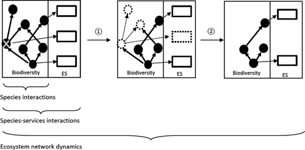

**Figure 1**

A conceptual description of an ecosystem network incorporating different types of interactions and dynamics. In this study, the ecosystem network dynamics include the trophic interactions (thick black arrows from prey to predator), the service provisioning links from species to ecosystem services (thin black arrows), and the ecosystem dynamics showing how the entire ecosystem changes with species losses. For example, species at risk of extinction or extirpation (indicated by the node with the “X”) due to external impacts (e.g. overfishing) can threaten persistence of other species (dotted nodes) in the food web if the lost species is their food resource. Similarly, this loss has consequences for the ecosystem services the species provides, as shown by the dotted rectangle (e.g. food production from a fishery), as in step ①. Then, as shown in step ②, secondary extinctions happens and lead to losses in services

Several features of ecosystem structure can influence the dynamics of ecological networks and, therefore, influence the strength of trade‐offs between ES and Bio strategies. First, a species' position in a food web (its trophic level) is a key determinant of food web stability (Binzer, Guill, Brose, & Rall, 2012; Johnson et al., 2014; Nichols & Garling, 2000) and influences biodiversity‐ecosystem functioning relationships (Duffy et al., 2007; Poisot, Mouquet, & Gravel, 2013). Therefore, different priorities for species protection could depend on whether a threatened species, or species providing a service, is from the top or the bottom trophic level in the food web. Second, food web robustness might increase with network connectedness (Dunne et al., 2002) with implications for service supply (Montoya, Rodríguez, & Hawkins, 2003). Thus, for more connected networks, ES strategy could tend to protect lower trophic level species that indirectly support multiple ES providers through network links, making it converge with the Bio strategy. Third, another factor that might affect the trade‐offs imposed by different strategies could be the number of ES within the system and for which protection is being sought. Multiple services could increase alignment between the two strategies by requiring more species for provision (Byrnes et al., 2014; Isbell et al., 2011; Zavaleta, Pasari, Hulvey, & Tilman, 2010). A strategy that optimises multiple services can then require protecting more species (Dee et al., 2017). We investigate how these structural features, trophic level, food web connectedness, and the number of services that ecosystem provides, influence trade‐offs between biodiversity and ecosystem services. More specifically, we tested three hypothesis:

> Hypothesis 1: The trophic level of the species providing services influences the relative performances of Bio and ES strategies.

> Hypothesis 2: The connectivity of the food web influences the relative performances of Bio and ES strategies.

> Hypothesis 3: The number ES considered influences the relative performances of Bio and ES strategies.

To address our questions and to explore the implications of biodiversity‐ecosystem trade‐offs, we analyse 360 simulated ecosystem networks and illustrate our approach using an empirical saltmarsh ecosystem network (see Section 2.4 and Figure S1, Table S1).

## 2 MATERIALS AND METHODS

### 2.1 Using network theory to model complex ecosystem structure

We considered an ecosystem with *G* species and *S* different services. A link between species represents a trophic relationship, from prey to predator. We assumed that cannibalism can occur, such that a species can interact with itself. Weighted arrows from a species node to a service node represent service provision by the species.

### 2.2 Markov Decision Processes to discover optimal management strategies

We framed the ecosystem management problem as an optimisation problem using Markov Decision Processes (MDP). MDP has been applied in solving many conservation problems, such as reserve site selection, species prioritisation or disease control (Chadès et al., 2011; Nicol, Sabbadin, Peyrard, & Chadès, 2017). Its main advantage over other approaches is that it provides optimal strategies that are state‐dependent and account for future stochastic dynamics of the system studied. Other ecosystem‐level management tools, such as Ecopath with Ecosim (e.g. Christensen & Walters, 2004; Heymans et al., 2016), are usually scenario based, parameter demanding, and not necessarily looking for the optimal strategy. In our case, our MDP formulation provides the optimal protection strategy using a small amount of information for ecosystem management, while varying several ecological features.

At the initial system state, we assumed that all species were extant. In each time period, species can go extinct or survive. The manager makes a decision, *a*<sup>*t*</sup>, about which species to protect at each time step, and we assumed that, due to budget constraints, only one species can be protected per time step and that protection is only efficient during a single time step. After action *a*<sup>*t*</sup> is applied at time *t*, species persist or go extinct at time *t* + 1, leading to a new state *x*<sup>*t* + 1</sup>. This transition process is stochastic and modelled by a transition probability distribution, P(*x*<sup>*t* + 1</sup>|*x*<sup>*t*</sup>, *a*<sup>*t*</sup>), which is the probability of the ecosystem passing from state *x*<sup>*t*</sup> to *x*<sup>*t* + 1</sup> when action *a*<sup>*t*</sup> is taken at time *t*. It is assumed that a species' survival at time *t* + 1 only depends on its current state, *g,* and its biodiversity neighbourhood, *N*<sub>Bio</sub>(*g*, *x*<sup>*t*</sup>), i.e., the extant species in the biodiversity neighbourhood of *g*. Therefore, each species has a different probability of extinction that depends on its position in the network and its biodiversity neighbourhood. For a basal species *g*, survival is guaranteed until the next time step if it is protected; and for a non‐basal species, protection guarantees survival until the next time step if at least one of its prey is extant (non‐empty biodiversity neighbourhood) (see Data S1).

We aimed to assess the species protection strategies for biodiversity and ecosystem services, defining a MDP for each objective: one with a biodiversity reward function to maximise the biodiversity outcomes (minimise species loss), *R*<sub>Bio</sub>(*x*<sup>*t*</sup>) and one with ecosystem services outcomes *R*<sub>ES</sub>(*x*<sup>*t*</sup>) to maximise ecosystem services provision (minimise the service loss or maintain as much as possible the initial service provision). Defining the value function with respect to those rewards will find the species protection strategy that will maximise, on a long‐term basis, either biodiversity or the services provision.

A strategy δ is a function determining which species to protect among the remaining ones. δ(*x*<sup>*t*</sup>) is the species to protect when extant species are described by a given ecosystem state at time *t*, *x*<sup>*t*</sup>. The “value” *V*<sub>δ</sub> of strategy δ is the expected sum over time of immediate rewards *R*(*x*<sup>*t*</sup>) obtained at each time step, when strategy δ is implemented (see Data S2). In the MDP framework, an optimal strategy δ*, maximising *V*<sub>δ</sub>, can be coded and computed using an MDP Matlab toolbox (Chadès, Chapron, Cros, Garcia, & Sabbadin, 2014) (see Data S3).

### 2.3 Criteria to assess the optimal biodiversity and ES strategies

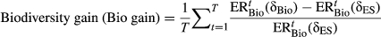

(1)

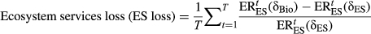

(2)

### 2.4 Simulations and case study

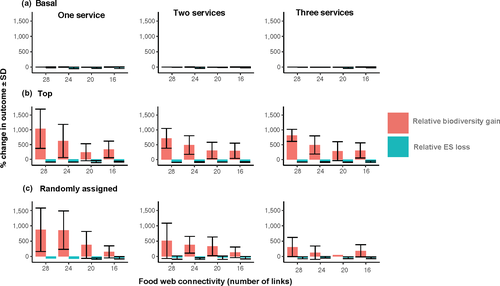

**Figure 2**

Results of 360 simulated ecosystem networks under Bio strategy and ES strategy. The *X* axis represents categories of four food web connectivities, corresponding to 9 species with 28 links (food web A1), 9 species with 24 links (food web A2), 9 species with 20 links (food web A3) and 9 species with 16 links (food web A4). The *Y* axis represents the relative values of biodiversity gain (Bio gain) and ecosystem services loss (ES loss) as a percentage when using the Bio strategy instead of the ES strategy. Panels a–c represent different trophic levels of the ES, from basal species, top predators, or species randomly assigned in the food web. Three columns represent the number of services considered in the network, from one service, two services, to three services. We simulated each of the four food web configurations (28, 24, 20, 16 links between species in the food web) 10 times using the niche model. Each bar shows the average biodiversity gain (in orange) or ES loss (in blue) of 10 simulated food webs, with error bars in black [Colour figure can be viewed at [wileyonlinelibrary.com](http://wileyonlinelibrary.com/)]

In the simulated networks, we assumed that the species providing ES were functionally equivalent, with the same contribution to the ES value they are linked to. We initially assumed constant baseline survival probability for all species in the food web, testing later how results change when relaxing this assumption. Specifically, we considered two additional scenarios: (a) exponentially decreasing baseline survival probabilities as species' trophic level increases, and (b) an endangered species mixed with common species in the food web (see Figure S2 and Table S5). Both assumptions could be modified with our approach when these parameters are known and available for particular case studies.

### 2.5 A Saltmarsh Case Study

We illustrated our framework using a case study of a saltmarsh ecosystem, using an empirical ecological network from Hechinger et al. (2011) for Carpinteria Salt Marsh (CSM), California, USA. Four major services were identified from this ecosystem: carbon sequestration, water filtration supporting improved water quality, shoreline protection, and fisheries production. We conducted a literature review to determine the relationship between each species in the network (excluding parasites and non‐free living organisms) and each of the studied ES (see Table S6). To make the analysis computationally feasible, we grouped 51 species into 12 organismal groups from Hechinger et al. (2011), with a few modifications (see Data S6), where an organismal group identifies a group of species that affect major ecosystem processes (Gitav & Noble, 1997).

We used published estimates of services values for the four services (Barbier et al., 2011). As for many ecosystem services in natural ecosystems, only approximations of the total value of a service provided by an ecosystem exist. Furthermore, in most natural systems, the exact contribution of each organismal group, and the species within them, to each ecosystem service are not known at the species or group level (Dee et al., 2017), with the exception of provisioning services that report direct market values by species (e.g. for a fishery). Due to current data limitations, we attributed ecosystem service values to different groups based on whether or not species within the group contribute to each service and, if so, each organismal group's average biomass for the three regulating services (carbon storage, water filtration, and shoreline protection) following approaches from Kremen (2005) and Balvanera et al. (2006). As additional information on the contribution of particular species, groups, and their diversity is available for these services, this information could be integrated into our modelling framework. Due to high uncertainty in the value of these ES, we used the upper and lower bounds of reported value estimates for each service. Therefore, we solved two MDP models, one using the lower bound values for all services (pessimistic case) and another using the upper bound values (optimistic case) (see Data S6). We also compared Bio and ES strategies in three cases: (a) constant baseline survival probability, (b) decreasing baseline survival probability as the trophic level of the species increases and (c) large discrepancies between baseline survival probabilities of species ranging from 0.1 to 0.9 (see Table S7).

## 3 RESULTS

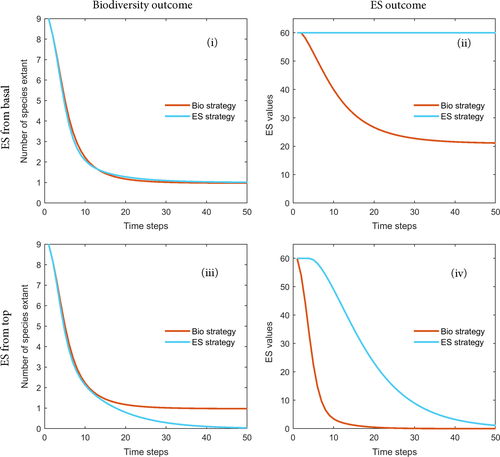

**Figure 3**

The expected number of species extant and the ecosystem service values over time under the Bio strategy and ES strategy. Results are shown for ecosystem network structures with nine species and 28 links. In subplots (i) and (ii), we consider that the ecosystem service is provided by species in the basal trophic level, while in subplots (iii) and (iv), we consider that the ecosystem service is provided by the species in the top trophic level [Colour figure can be viewed at [wileyonlinelibrary.com](http://wileyonlinelibrary.com/)]

To understand the influence of the trophic level of the species providing ES on Bio‐ES trade‐offs, we analysed which species the two strategies prioritise using a case in which an ecosystem has nine species, 28 trophic links, and a service originating from either a basal species or a top predator (see Figure S3). When a top predator provides the service (species 9), the ES strategy is to protect the extant species providing the services (see Figure S4 bottom). Conversely, the biodiversity strategy is more diversified, by protecting every species in the food web with similar frequency. The biodiversity strategy is closest to an ES strategy when the service comes from a basal species. More than 40% of the actions between the Bio strategy and ES strategy overlap in these cases, compared to only 22% where the service comes from a top predator (see Figure S4). Because food web stability and service provision all rely directly or indirectly on the basal species, both strategies might be expected to focus on protecting them. Nevertheless, this result shows that as the trophic level of the services increases, the strategy targeted towards ES protection gradually diverges from the biodiversity strategy (see Figure S5).

In the case study, the four services considered originate from different species groups, provided by vascular plants, algae, bivalves and fishes (Figure 4). As three of the four services come from low trophic levels, this salt marsh ecosystem is similar to a simulated ecosystem structure where services come from bottom trophic levels. The case study results are consistent with the patterns found on simulated ecosystem networks. We observed a 9% Bio gain and an 87% ES loss (a net loss of 78% in ES value) under the Bio strategy compared to the ES strategy, suggesting that the ES strategy performs better in maintaining ES provision with a relatively small biodiversity loss (see Table S8). We also found that, for this particular salt marsh ecosystem structure, considering the lower or upper estimates for ES values had little influence on the species protection strategies and trade‐offs between biodiversity and ES outcomes (see Table S8). Furthermore, as we vary the baseline survival probability for different species, we found that the ES strategy always remains the same but the Bio strategy gradually moves from protecting basal species to higher trophic level species (see Figure S8). As high trophic level species become more vulnerable, the ES strategy keeps protecting the services providers (species ID of 1, 2, 4, 10) while the Bio strategy moves towards high trophic levels where extinction would most likely happen.

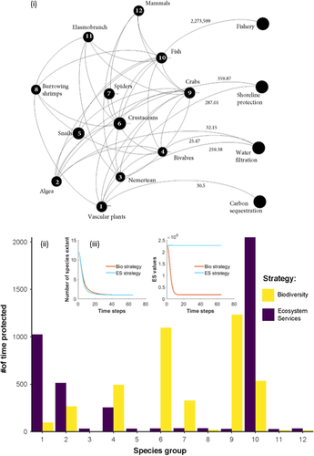

**Figure 4**

Case study results: a saltmarsh ecosystem network based on Hechinger et al. (2011) for Carpinteria SaltMarsh, California USA. The ecosystem network is represented on subplot (i), where we included 12 species groups with equal baseline survival probability and four ecosystem services (value in lower bound) in the ecosystem network. The links between species groups (left side) and services (right side) are weighted with estimated annual ecosystem services value range, in US dollars. The results of the case study are given in subplot (ii) and (iii) (Lower bound case, upper bound case is the same). We compared the biodiversity strategy and the ES strategy in terms of how frequently each species group is protected, that is, subplot (ii). And the corresponding biodiversity and ES outcomes are given in subplot (iii) nested within subplot (ii). Because three of the four services come from the basal species in this empirical ecosystem, subplot (ii) has the similar shape as subplot (i) and (ii) in Figure 3 [Colour figure can be viewed at [wileyonlinelibrary.com](http://wileyonlinelibrary.com/)]

## 4 DISCUSSION

Incorporating relationships between biodiversity and ecosystem services, and dependencies among species, is an important step for anticipating synergies and discrepancies between biodiversity conservation and ecosystem service provision (Balvanera et al., 2015; Dee et al., 2017). Previous work on ecosystem modelling such as Ecopath with Ecosim (Heymans et al., 2016) has incorporated ecosystem services within ecological networks and investigated some management scenarios and management outcomes, but they do not explore biodiversity‐ecosystem services trade‐offs nor do they utilise optimisation approaches. Here, we provide a novel approach that investigates management trade‐offs between biodiversity and ecosystem services using optimisation to find the best management given each objective, and use network theory to incorporate the dependencies of services on species and species on each other. We found that alignment between biodiversity and ecosystem service objectives depends on the trophic level of the species providing services. Greater alignment between ecosystem service and biodiversity outcomes occurs when basal species, which provide food resources for others species in the food web, also provide the services (Figure 2). This result arises because food web stability and service provision all rely directly or indirectly on the basal species and therefore an optimal ES strategy can attain similar levels of biodiversity as an optimal Biodiversity strategy while also generating gains for ES. This leads to a management win‐win. In contrast, alignment was reduced substantially when other trophic levels provided the services.

We did not observe any clear relationship between the number of services and consistency between the outcomes provided by each strategy—a result which departs from findings and predictions made by previous studies (e.g. Dee et al., 2017; Isbell et al., 2011; Zavaleta et al., 2010). Empirical studies finding that more species are needed to support a greater number of ecosystem functions have typically studied species from one trophic level (e.g. Isbell et al., 2011; Zavaleta et al., 2010). In contrast, we considered service provision by species from different trophic levels; a scenario that potentially creates trade‐offs among multiple services.

For simplicity, we explored relatively small ecosystem networks and made several assumptions, including constant baseline survival probability for each species. To test the robustness of our conclusions, we varied the baseline survival probability in two scenarios: (a) decreasing survival probabilities as species' trophic level increases (Dobson et al., 2006) and (b) mixing an endangered species with common species in the food web (see Table S5). Results from these two additional scenarios were consistent with our main results; we found more synergies between the Bio and ES strategies when bottom trophic level species provide services and more discrepancies when services come from top or random trophic levels (see Figure S2, Table S5). This approach could be extended to assign different survival probabilities based on empirical estimates, such as between generalists and specialists (Burkle, Marlin, & Knight, 2013) or plants and animals (Schleuning et al., 2016), to capture different extinction risk and vulnerability. These restrictions and others (e.g. protection of only one species per time step) could be relaxed to adapt our approach to different ecosystem management problems, though approximation methods may be required due to computational complexity.

We considered exclusively bottom‐up effects in our food webs. However, the importance of top‐down versus bottom‐up forces has been the topic of much research (e.g. Leopold et al., 2017). As an example, the effect of overfishing on predators can cascade down to impact lower trophic levels, decreasing food web stability or driving regime shifts (Gårdmark et al., 2015). Under this scenario, including top‐down effects could alter our results depending on the number of trophic levels in the ecosystem. Previous studies, however, also show that 80% of secondary extinctions in food webs can be predicted by a Bayesian networks approach that only considers bottom‐up effects, as compared to a full dynamic model of the food web that captures these top‐down processes (Eklöf, Tang, & Allesina, 2013). Given this finding, our model is likely to capture the majority of secondary extinction risks. The impact of secondary extinctions may also be influenced by a species ability to adapt after an initial change to the ecosystem. For example, in the absence of their preferred prey a species may switch to a new prey resource. Allowing such a phenomenon, known as rewiring, is likely to increase the stability of the system (Timóteo, Ramos, Vaughan, & Memmott, 2016) and if included in our model would potentially decrease the loss of biodiversity and the trade‐offs observed between the biodiversity and ES strategies. Another component that may alter the structure of the food web is the types of interactions included. Currently, we focus on trophic interactions, such as predator–prey relationships; however, the inclusion of other non‐trophic interactions such as mutualism may alter our discrepancies between strategies.

Our work offers quantitative insights into the current debate between the objectives of biodiversity conservation and ES provisioning, and how the structure of ecosystems influence trade‐offs or win‐win outcomes. Our work highlights that win‐win outcomes for ES and Biodiversity are possible, even when optimising for just one of these objectives, consistent with previous studies (e.g. Dee et al., 2017; Nelson et al., 2008; Polasky et al., 2012). Our results also highlight that achieving such outcomes is far from guaranteed and depends on both network structure and the trophic level of the service providers. By coupling ES and biodiversity in a network, our modelling framework provides a scaffold for future investigations of optimal ecosystem management, to inform decision‐making to conserve both biodiversity and the benefits to people that they provide.

## ACKNOWLEDGEMENTS

We thank Fleur Maseyk for her insightful comments on ecosystem models, and Chris Baker for feedback that improved this manuscript. We also thank Stefano Allesina, Steve Miller, György Barabás, for early conversation on this work. Finally, we thank the Associate Editor and two anonymous reviewers for helpful comments on this study. E.M.‐M. was funded by an ARC Future Fellowship.

## AUTHORS' CONTRIBUTIONS

H.X. designed the study, did the analysis, and led the writing; L.E.D. contributed to the research questions and hypotheses, designed and provided the case study, and contributed to interpretation of results and manuscript revisions; I.C. contributed to mechanistic insights behind the results; N.P. and R.S. contributed to the development of the network and the MDP models; M.S. contributed to the interpretation of results, and manuscript revision; I.C. and E.M.‐M. initiated and supervised the study. All authors contributed to the drafts and gave final approval for publication.

## DATA ACCESSIBILITY

The saltmarsh ecological network data are available in Food webs including parasites, biomass, body sizes, and life stages for three California/Baja California estuaries https://doi.org/10.1890/10-1383.1 (Hechinger et al., 2011).

Our Matlab code to reproduce the simulation is available via figshare https://doi.org/10.6084/m9.figshare.6390557.v1 (Xiao, 2018).

## Citing Literature

[figure not shown]

[Volume55, Issue5](https://besjournals.onlinelibrary.wiley.com/toc/13652664/2018/55/5)

September 2018

Pages 2160-2170

### Metrics

- Citations: 9

### Details

  © 2018 The Authors. Journal of Applied Ecology © 2018 British Ecological Society

[figure not shown]